# Complete Code Finalized

```python
import pandas as pd
import numpy as np
import matplotlib.pyplot as plt
import seaborn as sns
import warnings
warnings.filterwarnings('ignore')
```

```python
data = pd.read_csv("hiv_joined_data.csv", encoding='latin1')

data.head()
```

|  | Record ID | Data Type | Age Category Code | Country Code | Geographic Area | Geographic Code | Reference Date | Population Subgroup | Subpop Code | Virus Type | ... | Comments | Specimen Type | Test Type | Quality | Site Name | Country | Author | Year | Title | Publication Information |
| --- | --- | --- | --- | --- | --- | --- | --- | --- | --- | --- | --- | --- | --- | --- | --- | --- | --- | --- | --- | --- | --- |
| 0 | 2 | P | A | SEN | Dakar | C | 1991-1993 | Pregnant women | G | HIV2 | ... | Apr. 91 - Jan. 93. | B | ELISA, WB | A | Le Dantec Hospital | Senegal | Abbott, R. C., A. Ndour-Sarr, A. Diouf, et al. | 1994 | Risk Factors for HIV-1 and HIV-2 Infection in ... | Journal of Acquired Immune Deficiency Syndrome... |
| 1 | 3 | P | A | SEN | Dakar | C | 1991-1993 | Pregnant women | G | HIV1&2 | ... | Apr. 91 - Jan. 93. | B | ELISA, WB | A | Le Dantec Hospital | Senegal | Abbott, R. C., A. Ndour-Sarr, A. Diouf, et al. | 1994 | Risk Factors for HIV-1 and HIV-2 Infection in ... | Journal of Acquired Immune Deficiency Syndrome... |
| 2 | 1 | P | A | SEN | Dakar | C | 1991-1993 | Pregnant women | G | HIV1 | ... | Apr. 91 - Jan. 93. | B | ELISA, WB | A | Le Dantec Hospital | Senegal | Abbott, R. C., A. Ndour-Sarr, A. Diouf, et al. | 1994 | Risk Factors for HIV-1 and HIV-2 Infection in ... | Journal of Acquired Immune Deficiency Syndrome... |
| 3 | 6 | R | A | ZAF | National | N | 1988 | Cumulative AIDS cases - IVDU | I | AIDS | ... | Reported as of Nov. 88. | NaN | NaN | A | National | South Africa | Advisory Group, The | 1989 | Update: AIDS in the RSA (November 1988) | South African Medical Journal, vol. 75, p. 95. |
| 4 | 4 | R | A | ZAF | National | N | 1988 | Cumulative pediatric AIDS cases | C | AIDS | ... | Reported as of Nov. 88. | NaN | NaN | A | National | South Africa | Advisory Group, The | 1989 | Update: AIDS in the RSA (November 1988) | South African Medical Journal, vol. 75, p. 95. |

5 rows × 29 columns

```python
data.info()
```

```
<class 'pandas.core.frame.DataFrame'>
RangeIndex: 226320 entries, 0 to 226319
Data columns (total 29 columns):
 #   Column                   Non-Null Count   Dtype
---  ------                   --------------   -----
 0   Record ID                226320 non-null  int64
 1   Data Type                226320 non-null  object
 2   Age Category Code        226320 non-null  object
 3   Country Code             226320 non-null  object
 4   Geographic Area          226320 non-null  object
 5   Geographic Code          226320 non-null  object
 6   Reference Date           226320 non-null  object
 7   Population Subgroup      226320 non-null  object
 8   Subpop Code              226320 non-null  object
 9   Virus Type               226320 non-null  object
```

[output cut: 21 more lines]

```python
data_temp = data
data_HIV = data[["Geographic Area", "Reference Date", "Population Subgroup", "Virus Type", "Age", "Sex", "Prevalence Rate",
             "Country", "Site Name"]]

data_AIDS = data[["Geographic Area", "Reference Date", "Population Subgroup", "Virus Type", "Age", "Sex", "Num Cases", "Num of Deaths",
                  "Country", "Site Name"]]
```

```python
# Replace -1.0 with NaN across the entire DataFrame
data_HIV.replace(-1.0, np.nan, inplace=True)
data_HIV.replace("-1", np.nan, inplace=True)

# Replace -1.0 with NaN across the entire DataFrame
data_AIDS.replace(-1.0, np.nan, inplace=True)
data_AIDS.replace("-1", np.nan, inplace=True)
```

```python
data_HIV.isna().sum()
```

```
Geographic Area            0
Reference Date             0
Population Subgroup        0
Virus Type                 0
Age                        0
Sex                        0
Prevalence Rate        28286
Country                    0
Site Name                  0
dtype: int64
```

```python
data_HIV = data_HIV.dropna()
data_AIDS = data_AIDS.dropna()
```

```python
data_AIDS['Num Cases'] = data_AIDS['Num Cases'].str.replace(',', '')
data_AIDS['Num Cases'] = pd.to_numeric(data_AIDS['Num Cases'])
```

## Comparison of HIV & AIDS

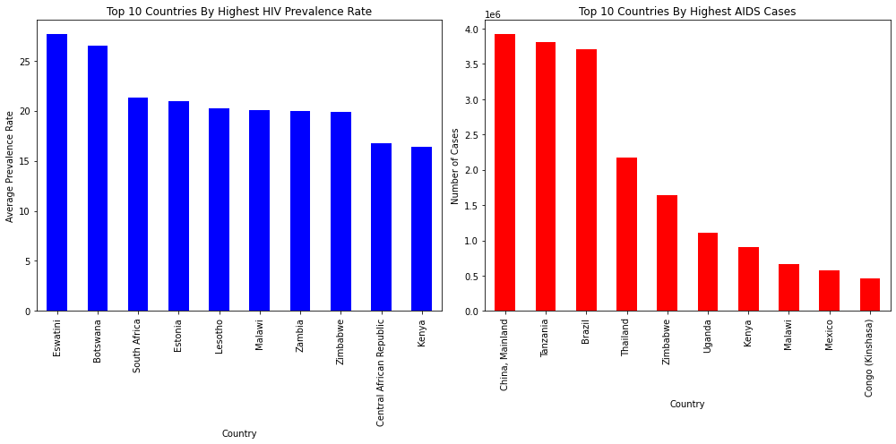

```python
# Find top 10 countries for HIV and AIDS
top_10_hiv = data_HIV[data_HIV['Virus Type'] == 'HIV'].groupby('Country')['Prevalence Rate'].mean().nlargest(10)
top_10_aids = data_AIDS.groupby('Country')['Num Cases'].sum().nlargest(10)

# Plot
plt.figure(figsize=(14, 7))

plt.subplot(1, 2, 1)
top_10_hiv.plot(kind='bar', color='blue')
plt.title('Top 10 Countries By Highest HIV Prevalence Rate')
plt.xlabel('Country')
plt.ylabel('Average Prevalence Rate')

plt.subplot(1, 2, 2)
top_10_aids.plot(kind='bar', color='red')
plt.title('Top 10 Countries By Highest AIDS Cases')
plt.xlabel('Country')
plt.ylabel('Number of Cases')

plt.tight_layout()
plt.show()
```

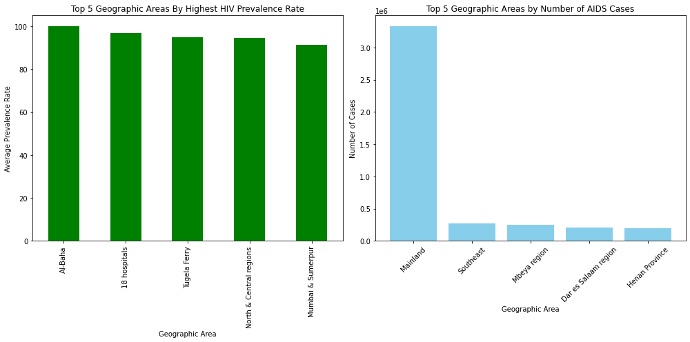

```python
# Find top 5 geographic areas for HIV and AIDS
top_5_hiv_areas = data_HIV.groupby('Geographic Area')['Prevalence Rate'].mean().nlargest(5)
# Group by 'Geographic Area' and sum 'Num Cases'
top_5_aids_areas = data_AIDS.groupby('Geographic Area')['Num Cases'].sum().nlargest(10).reset_index()

# Remove rows where 'Geographic Area' column has 'National' or 'Not specified'
top_5_aids_areas_filtered = top_5_aids_areas[~top_5_aids_areas['Geographic Area'].isin(['National', 'Not specified'])]

# Select the top 5 areas from the filtered data
top_5_aids_areas_filtered = top_5_aids_areas_filtered.head(5)


# Plot
plt.figure(figsize=(14, 7))

plt.subplot(1, 2, 1)
top_5_hiv_areas.plot(kind='bar', color='green')
plt.title('Top 5 Geographic Areas By Highest HIV Prevalence Rate')
plt.xlabel('Geographic Area')
plt.ylabel('Average Prevalence Rate')

plt.subplot(1, 2, 2)
plt.bar(top_5_aids_areas_filtered['Geographic Area'], top_5_aids_areas_filtered['Num Cases'], color='skyblue')
plt.xlabel('Geographic Area')
plt.ylabel('Number of Cases')
plt.title('Top 5 Geographic Areas by Number of AIDS Cases')
plt.xticks(rotation=45)

plt.tight_layout()
plt.show()
```

```python
top_5_hiv_areas
```

```
Geographic Area
Al-Baha                    99.990
18 hospitals               96.720
Tugela Ferry               94.995
North & Central regions    94.670
Mumbai & Sumerpur          91.430
Name: Prevalence Rate, dtype: float64
```

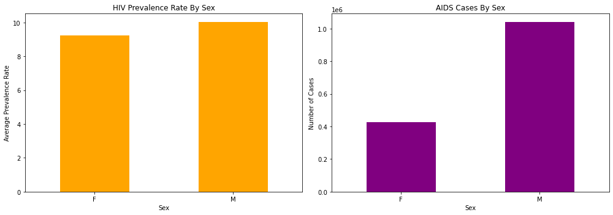

```python
# Find top 5 population subgroups for HIV and AIDS
top_5_hiv_subgroups = data_HIV[data_HIV['Sex'].isin(['M', 'F'])].groupby('Sex')['Prevalence Rate'].mean()
top_5_aids_subgroups = data_AIDS[data_AIDS['Sex'].isin(['M', 'F'])].groupby('Sex')['Num Cases'].sum()

# Sort categories explicitly
top_5_hiv_subgroups = top_5_hiv_subgroups[['F', 'M']]
top_5_aids_subgroups = top_5_aids_subgroups[['F', 'M']]

# Plot
plt.figure(figsize=(14, 5))

plt.subplot(1, 2, 1)
top_5_hiv_subgroups.plot(kind='bar', color='orange')
plt.title('HIV Prevalence Rate By Sex')
plt.xlabel('Sex')
plt.ylabel('Average Prevalence Rate')
plt.xticks(rotation=0)

plt.subplot(1, 2, 2)
top_5_aids_subgroups.plot(kind='bar', color='purple')
plt.title('AIDS Cases By Sex')
plt.xlabel('Sex')
plt.ylabel('Number of Cases')
plt.xticks(rotation=0)

plt.tight_layout()
plt.show()
```

```python
# Function to calculate the midpoint year
def calculate_midpoint(date_str):
    if '-' in date_str:
        start, end = date_str.split('-')
        if start.isdigit() and end.isdigit():
            return (int(start) + int(end)) // 2
    elif '/' in date_str or '&' in date_str:
        return np.nan  # Ignore special cases for simplicity
    elif date_str.isdigit():
        return int(date_str)
    return np.nan

# Apply the function to create a new column with midpoints
data_HIV['Midpoint Year'] = data_HIV['Reference Date'].apply(calculate_midpoint)

# Filter out rows where the midpoint year couldn't be calculated
data_HIV = data_HIV.dropna(subset=['Midpoint Year'])

# Apply the function to create a new column with midpoints
data_AIDS['Midpoint Year'] = data_AIDS['Reference Date'].apply(calculate_midpoint)

# Filter out rows where the midpoint year couldn't be calculated
data_AIDS = data_AIDS.dropna(subset=['Midpoint Year'])
```

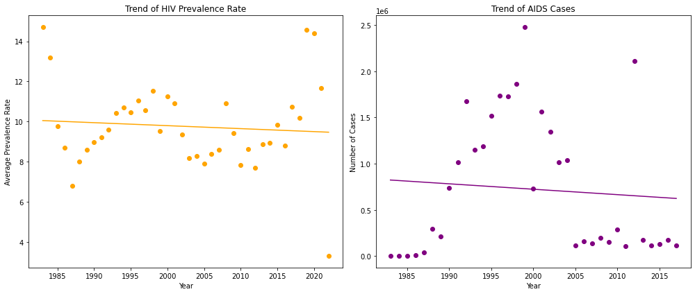

```python
# Filter out data before 1983
data_HIV = data_HIV[data_HIV['Midpoint Year'] >= 1983]
data_AIDS = data_AIDS[data_AIDS['Midpoint Year'] >= 1983]

# Calculate trends
hiv_trend = data_HIV.groupby('Midpoint Year')['Prevalence Rate'].mean()
aids_trend = data_AIDS.groupby('Midpoint Year')['Num Cases'].sum()

# Function to add a regression line
def add_regression_line(x, y, color):
    m, b = np.polyfit(x, y, 1)
    plt.plot(x, m*x + b, color=color)

# Plot
plt.figure(figsize=(14, 6))

plt.subplot(1, 2, 1)
plt.scatter(hiv_trend.index, hiv_trend, color='orange')
add_regression_line(hiv_trend.index, hiv_trend, 'orange')
plt.title('Trend of HIV Prevalence Rate')
plt.xlabel('Year')
plt.ylabel('Average Prevalence Rate')

plt.subplot(1, 2, 2)
plt.scatter(aids_trend.index, aids_trend, color='purple')
add_regression_line(aids_trend.index, aids_trend, 'purple')
plt.title('Trend of AIDS Cases')
plt.xlabel('Year')
plt.ylabel('Number of Cases')

plt.tight_layout()
plt.show()
```

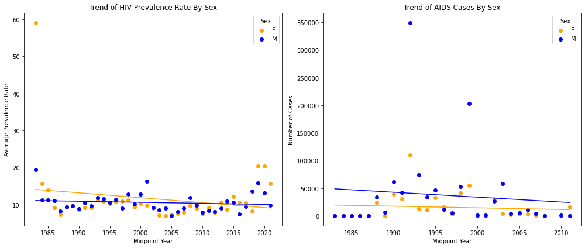

```python
# Calculate trends
hiv_trend = data_HIV[data_HIV['Sex'].isin(['F', 'M'])].groupby(['Midpoint Year', 'Sex'])['Prevalence Rate'].mean().unstack()
aids_trend = data_AIDS[data_AIDS['Sex'].isin(['F', 'M'])].groupby(['Midpoint Year', 'Sex'])['Num Cases'].sum().unstack()

aids_trend['F'].fillna(aids_trend['F'].mean(), inplace=True)

# Plot
plt.figure(figsize=(14, 6))

# Plot HIV Prevalence Rate trends by Sex
plt.subplot(1, 2, 1)
for sex, color in zip(hiv_trend.columns, ['orange', 'blue']):
    plt.scatter(hiv_trend.index, hiv_trend[sex], label=sex, color=color)
    add_regression_line(hiv_trend.index, hiv_trend[sex], color)
plt.title('Trend of HIV Prevalence Rate By Sex')
plt.xlabel('Midpoint Year')
plt.ylabel('Average Prevalence Rate')
plt.legend(title='Sex')

# Plot AIDS Cases trends by Sex
plt.subplot(1, 2, 2)
for sex, color in zip(aids_trend.columns, ['orange', 'blue']):
    plt.scatter(aids_trend.index, aids_trend[sex], label=sex, color=color)
    add_regression_line(aids_trend.index, aids_trend[sex], color)
plt.title('Trend of AIDS Cases By Sex')
plt.xlabel('Midpoint Year')
plt.ylabel('Number of Cases')
plt.legend(title='Sex')

plt.tight_layout()
plt.show()
```

```python
data = pd.read_csv("AIDS_Classification.csv")
data.head()
```

|  | time | trt | age | wtkg | hemo | homo | drugs | karnof | oprior | z30 | ... | str2 | strat | symptom | treat | offtrt | cd40 | cd420 | cd80 | cd820 | infected |
| --- | --- | --- | --- | --- | --- | --- | --- | --- | --- | --- | --- | --- | --- | --- | --- | --- | --- | --- | --- | --- | --- |
| 0 | 948 | 2 | 48 | 89.8128 | 0 | 0 | 0 | 100 | 0 | 0 | ... | 0 | 1 | 0 | 1 | 0 | 422 | 477 | 566 | 324 | 0 |
| 1 | 1002 | 3 | 61 | 49.4424 | 0 | 0 | 0 | 90 | 0 | 1 | ... | 1 | 3 | 0 | 1 | 0 | 162 | 218 | 392 | 564 | 1 |
| 2 | 961 | 3 | 45 | 88.4520 | 0 | 1 | 1 | 90 | 0 | 1 | ... | 1 | 3 | 0 | 1 | 1 | 326 | 274 | 2063 | 1893 | 0 |
| 3 | 1166 | 3 | 47 | 85.2768 | 0 | 1 | 0 | 100 | 0 | 1 | ... | 1 | 3 | 0 | 1 | 0 | 287 | 394 | 1590 | 966 | 0 |
| 4 | 1090 | 0 | 43 | 66.6792 | 0 | 1 | 0 | 100 | 0 | 1 | ... | 1 | 3 | 0 | 0 | 0 | 504 | 353 | 870 | 782 | 0 |

5 rows × 23 columns

## AIDS Infection Analysis

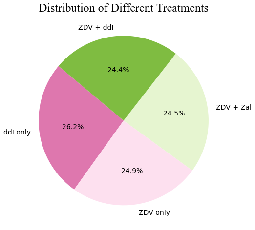

```python
# Count the values in the 'trt' column
trt = data['trt'].value_counts().reset_index()
trt.columns = ['trt', 'count']

# Map numerical values to descriptive labels
label_map = {0: "ZDV only", 1: "ZDV + ddI", 2: "ZDV + Zal", 3: "ddI only"}

# Replace numerical labels with descriptive labels
trt['trt'] = trt['trt'].map(label_map)

# Create a pie chart using matplotlib and seaborn for color palettes
plt.figure(figsize=(8, 8))
colors = sns.color_palette("PiYG", len(trt))

plt.pie(
    trt['count'],
    labels=trt['trt'],
    autopct='%1.1f%%',
    startangle=140,
    colors=colors,
    textprops={'fontsize': 14, 'color': 'black'}
)

plt.title("Distribution of Different Treatments", fontsize=24, family="Times New Roman", color='black')
plt.show()
```

The treatment indicator provides information about the type of antiretroviral treatment regimen patients in the dataset are receiving:

0 = ZDV only: Patients with this indicator are being treated only with Zidovudine (ZDV), also known as AZT.

1 = ZDV + ddI: Patients with this indicator are being treated with a combination of Zidovudine (ZDV) and Didanosine (ddI).

2 = ZDV + Zal: Patients with this indicator are being treated with a combination of Zidovudine (ZDV) and Zalcitabine (Zal).

3 = ddI only: Patients with this indicator are being treated only with Didanosine (ddI).

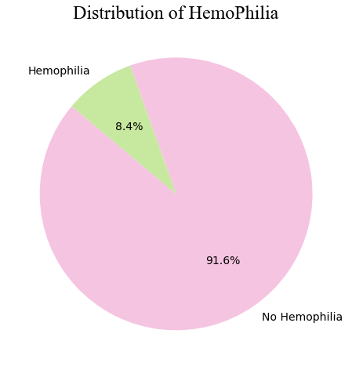

```python
# Count the values in the 'trt' column
trt = data['hemo'].value_counts().reset_index()
trt.columns = ['hemo', 'count']

# Map numerical values to descriptive labels
label_map = {0: "No Hemophilia", 1: "Hemophilia"}

# Replace numerical labels with descriptive labels
trt['hemo'] = trt['hemo'].map(label_map)

# Create a pie chart using matplotlib and seaborn for color palettes
plt.figure(figsize=(8, 8))
colors = sns.color_palette("PiYG", len(trt))

plt.pie(
    trt['count'],
    labels=trt['hemo'],
    autopct='%1.1f%%',
    startangle=140,
    colors=colors,
    textprops={'fontsize': 14, 'color': 'black'}
)

plt.title("Distribution of HemoPhilia", fontsize=24, family="Times New Roman", color='black')
plt.show()
```

It refers to a genetic disorder. Individuals with hemophilia lack certain proteins. As a result, they are at an increased risk of excessive bleeding, both internally and externally, even from minor injuries. Majority of the patients do not have hemophilia as per the pie chart above.

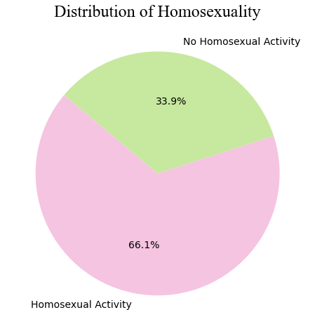

```python
# Count the values in the 'trt' column
trt = data['homo'].value_counts().reset_index()
trt.columns = ['homo', 'count']

# Map numerical values to descriptive labels
label_map = {0: "No Homosexual Activity", 1: "Homosexual Activity"}

# Replace numerical labels with descriptive labels
trt['homo'] = trt['homo'].map(label_map)

# Create a pie chart using matplotlib and seaborn for color palettes
plt.figure(figsize=(8, 8))
colors = sns.color_palette("PiYG", len(trt))

plt.pie(
    trt['count'],
    labels=trt['homo'],
    autopct='%1.1f%%',
    startangle=140,
    colors=colors,
    textprops={'fontsize': 14, 'color': 'black'}
)

plt.title("Distribution of Homosexuality", fontsize=24, family="Times New Roman", color='black')
plt.show()
```

Homosexual activity refers to sexual activity between individuals of the same sex, often between men. Historically, homosexual activity has been associated with a higher risk of HIV transmission due to various factor. Majority of the patients have indulged in homosexual activity as per the pie chart above.

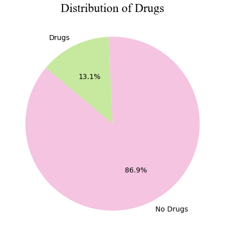

```python
# Count the values in the 'trt' column
trt = data['drugs'].value_counts().reset_index()
trt.columns = ['drugs', 'count']

# Map numerical values to descriptive labels
label_map = {0: "No Drugs", 1: "Drugs"}

# Replace numerical labels with descriptive labels
trt['drugs'] = trt['drugs'].map(label_map)

# Create a pie chart using matplotlib and seaborn for color palettes
plt.figure(figsize=(8, 8))
colors = sns.color_palette("PiYG", len(trt))

plt.pie(
    trt['count'],
    labels=trt['drugs'],
    autopct='%1.1f%%',
    startangle=140,
    colors=colors,
    textprops={'fontsize': 14, 'color': 'black'}
)

plt.title("Distribution of Drugs", fontsize=24, family="Times New Roman", color='black')
plt.show()
```

Majority of the patients do not have a history of drug use as per the pie chart above.

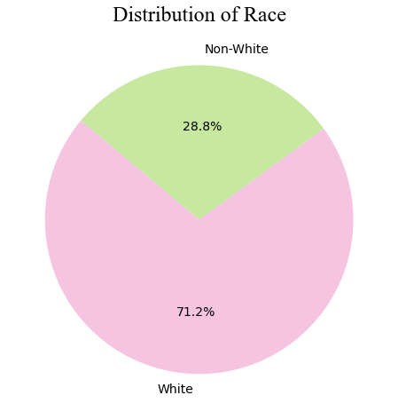

```python
# Count the values in the 'trt' column
trt = data['race'].value_counts().reset_index()
trt.columns = ['race', 'count']

# Map numerical values to descriptive labels
label_map = {0: "White", 1: "Non-White"}

# Replace numerical labels with descriptive labels
trt['race'] = trt['race'].map(label_map)

# Create a pie chart using matplotlib and seaborn for color palettes
plt.figure(figsize=(8, 8))
colors = sns.color_palette("PiYG", len(trt))

plt.pie(
    trt['count'],
    labels=trt['race'],
    autopct='%1.1f%%',
    startangle=140,
    colors=colors,
    textprops={'fontsize': 14, 'color': 'black'}
)

plt.title("Distribution of Race", fontsize=24, family="Times New Roman", color='black')
plt.show()
```

Majority of the patients are white.

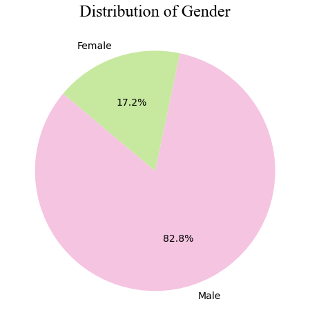

```python
# Count the values in the 'trt' column
trt = data['gender'].value_counts().reset_index()
trt.columns = ['gender', 'count']

# Map numerical values to descriptive labels
label_map = {0: "Female", 1: "Male"}

# Replace numerical labels with descriptive labels
trt['gender'] = trt['gender'].map(label_map)

# Create a pie chart using matplotlib and seaborn for color palettes
plt.figure(figsize=(8, 8))
colors = sns.color_palette("PiYG", len(trt))

plt.pie(
    trt['count'],
    labels=trt['gender'],
    autopct='%1.1f%%',
    startangle=140,
    colors=colors,
    textprops={'fontsize': 14, 'color': 'black'}
)

plt.title("Distribution of Gender", fontsize=24, family="Times New Roman", color='black')
plt.show()
```

Majority of patients are male.

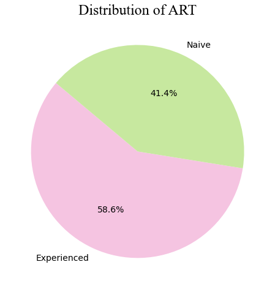

```python
# Count the values in the 'trt' column
trt = data['str2'].value_counts().reset_index()
trt.columns = ['str2', 'count']

# Map numerical values to descriptive labels
label_map = {0: "Naive", 1: "Experienced"}

# Replace numerical labels with descriptive labels
trt['str2'] = trt['str2'].map(label_map)

# Create a pie chart using matplotlib and seaborn for color palettes
plt.figure(figsize=(8, 8))
colors = sns.color_palette("PiYG", len(trt))

plt.pie(
    trt['count'],
    labels=trt['str2'],
    autopct='%1.1f%%',
    startangle=140,
    colors=colors,
    textprops={'fontsize': 14, 'color': 'black'}
)

plt.title("Distribution of ART", fontsize=24, family="Times New Roman", color='black')
plt.show()
```

The variable str2 represents the antiretroviral history of individuals, specifically whether they are "naive" or "experienced" with antiretroviral therapy (ART).

Naive (0): Individuals categorized as "naive" have not previously received antiretroviral therapy.

Experienced (1): Individuals categorized as "experienced" have a history of receiving antiretroviral therapy.

Majority of patients were experienced and were previously treated with ART medication

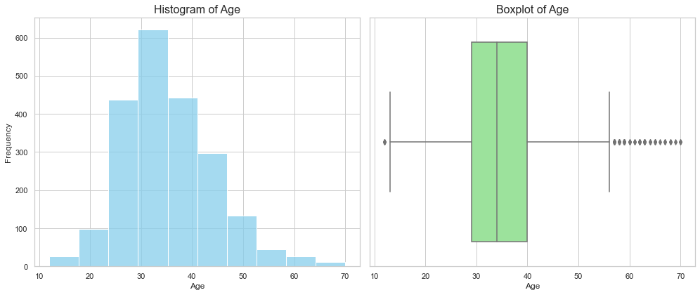

```python
# Set the style of seaborn
sns.set(style="whitegrid")

# Create the figure and axes
fig, ax = plt.subplots(1, 2, figsize=(14, 6))

# Plot the histogram
sns.histplot(data['age'], bins=10, kde=False, color='skyblue', ax=ax[0])
ax[0].set_title("Histogram of Age", fontsize=16)
ax[0].set_xlabel("Age", fontsize=12)
ax[0].set_ylabel("Frequency", fontsize=12)

# Plot the boxplot
sns.boxplot(x=data['age'], color='lightgreen', ax=ax[1])
ax[1].set_title("Boxplot of Age", fontsize=16)
ax[1].set_xlabel("Age", fontsize=12)

# Adjust layout
plt.tight_layout()

# Show the plot
plt.show()
```

It can be seen that age is normally distributed

There are no missing values

Max values goes up to 70 but some outliers are present in the data

Mean and median are about the same hence we can conclude that the outliers are not affecting the data

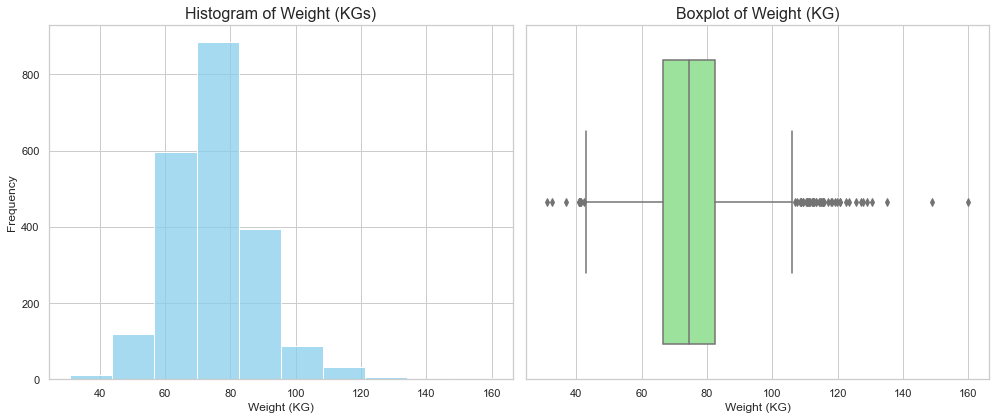

```python
# Set the style of seaborn
sns.set(style="whitegrid")

# Create the figure and axes
fig, ax = plt.subplots(1, 2, figsize=(14, 6))

# Plot the histogram
sns.histplot(data['wtkg'], bins=10, kde=False, color='skyblue', ax=ax[0])
ax[0].set_title("Histogram of Weight (KGs)", fontsize=16)
ax[0].set_xlabel("Weight (KG)", fontsize=12)
ax[0].set_ylabel("Frequency", fontsize=12)

# Plot the boxplot
sns.boxplot(x=data['wtkg'], color='lightgreen', ax=ax[1])
ax[1].set_title("Boxplot of Weight (KG)", fontsize=16)
ax[1].set_xlabel("Weight (KG)", fontsize=12)

# Adjust layout
plt.tight_layout()

# Show the plot
plt.show()
```

Most of the outliers are present beyond the weight of 100kg. The distribution is slightly positively skewewd. "No missing values". As most of the outliers in the Age column are present beyond the age of 60, hence maybe most of the people belonging to that age group are over 100 kg.

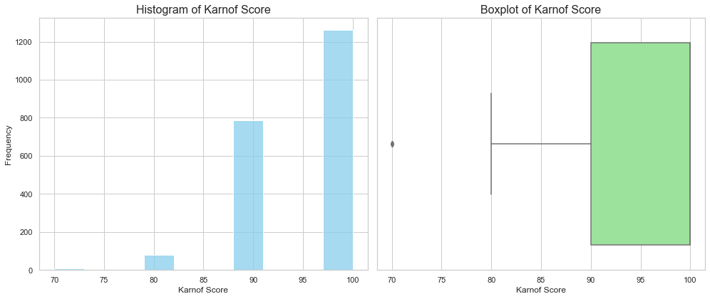

```python
# Set the style of seaborn
sns.set(style="whitegrid")

# Create the figure and axes
fig, ax = plt.subplots(1, 2, figsize=(14, 6))

# Plot the histogram
sns.histplot(data['karnof'], bins=10, kde=False, color='skyblue', ax=ax[0])
ax[0].set_title("Histogram of Karnof Score", fontsize=16)
ax[0].set_xlabel("Karnof Score", fontsize=12)
ax[0].set_ylabel("Frequency", fontsize=12)

# Plot the boxplot
sns.boxplot(x=data['karnof'], color='lightgreen', ax=ax[1])
ax[1].set_title("Boxplot of Karnof Score", fontsize=16)
ax[1].set_xlabel("Karnof Score", fontsize=12)

# Adjust layout
plt.tight_layout()

# Show the plot
plt.show()
```

The distribution is negatively skewed as most of the patients have karnfosky score of 100 which is a good sign. 100 means Normal, no evidence of disease, able to carry on normal activities without any restrictions.

```python
data_temp = data.copy()
data_temp['hemo'] = data_temp['hemo'].replace({0: 'No-Hemophilia', 1: 'Hemophilia'})
data_temp['infected'] = data_temp['infected'].replace({0: 'AIDS Infected', 1: 'Not Infected'})
data_temp['str2'] = data_temp['str2'].replace({0: "Naive", 1: "Experienced"})
data_temp['gender'] = data_temp['gender'].replace({0: "Female", 1: "Male"})
data_temp['race'] = data_temp['race'].replace({0: "White", 1: "Non-White"})
data_temp['drugs'] = data_temp['drugs'].replace({0: "No Drugs", 1: "Drugs"})
data_temp['symptom'] = data_temp['symptom'].replace({0: "No Symptoms", 1: "Symptoms"})
data_temp['homo'] = data_temp['homo'].replace({0: "No Homosexual Activity", 1: "Homosexual Activity"})
data_temp['trt'] = data_temp['trt'].replace({0: "ZDV only", 1: "ZDV + ddI", 2: "ZDV + Zal", 3: "ddI only"})
```

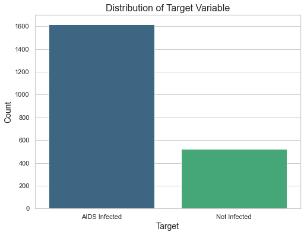

```python
# Set the style of seaborn
sns.set(style="whitegrid")

# Create the count plot
plt.figure(figsize=(8, 6))
sns.countplot(x='infected', data=data_temp, palette='viridis')

# Customize the plot
plt.title("Distribution of Target Variable", fontsize=16)
plt.xlabel("Target", fontsize=14)
plt.ylabel("Count", fontsize=14)

# Show the plot
plt.show()
```

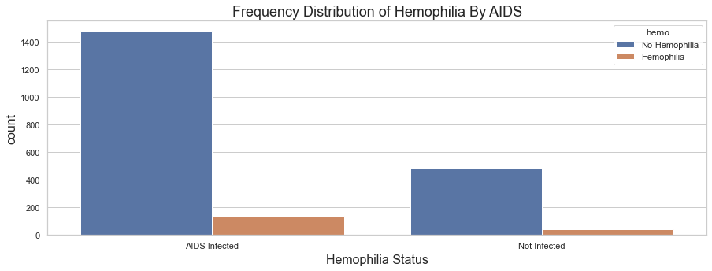

```python
plt.figure(figsize = (15,5))
sns.countplot(hue = 'hemo' , x = 'infected', data = data_temp)
plt.title("Frequency Distribution of Hemophilia By AIDS", fontsize = 18)
plt.xlabel("Hemophilia Status", fontsize = 16)
plt.ylabel("count", fontsize = 16)
plt.show()
```

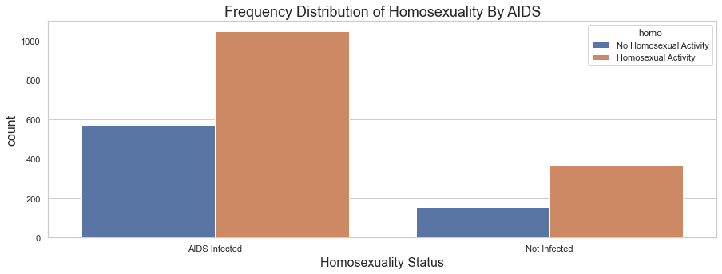

```python
plt.figure(figsize = (15,5))
sns.countplot(hue = 'homo' , x = 'infected', data = data_temp)
plt.title("Frequency Distribution of Homosexuality By AIDS", fontsize = 18)
plt.xlabel("Homosexuality Status", fontsize = 16)
plt.ylabel("count", fontsize = 16)
plt.show()
```

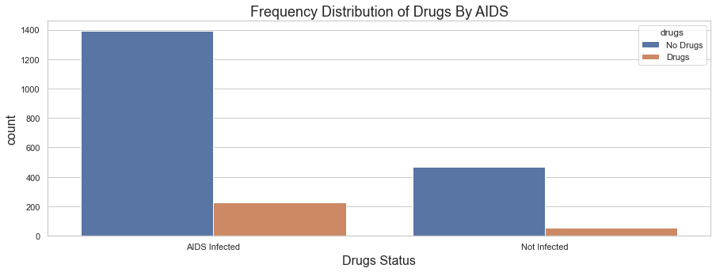

```python
plt.figure(figsize = (15,5))
sns.countplot(hue = 'drugs' , x = 'infected', data = data_temp)
plt.title("Frequency Distribution of Drugs By AIDS", fontsize = 18)
plt.xlabel("Drugs Status", fontsize = 16)
plt.ylabel("count", fontsize = 16)
plt.show()
```

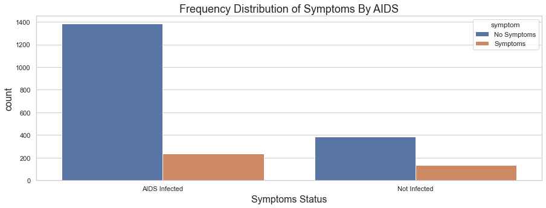

```python
plt.figure(figsize = (15,5))
sns.countplot(hue = 'symptom' , x = 'infected', data = data_temp)
plt.title("Frequency Distribution of Symptoms By AIDS", fontsize = 18)
plt.xlabel("Symptoms Status", fontsize = 16)
plt.ylabel("count", fontsize = 16)
plt.show()
```

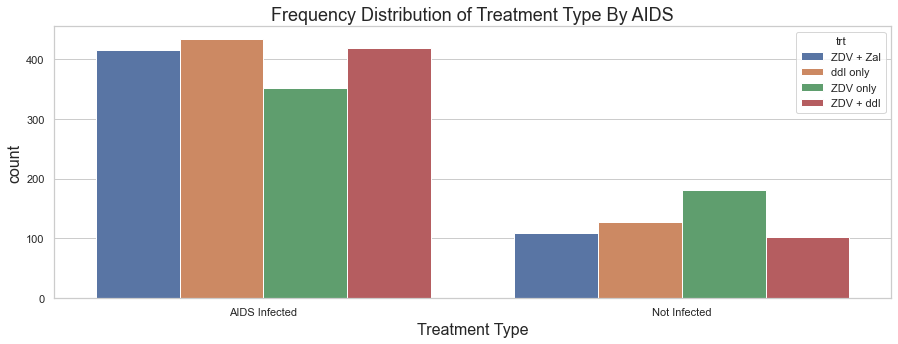

```python
plt.figure(figsize = (15,5))
sns.countplot(hue = 'trt' , x = 'infected', data = data_temp)
plt.title("Frequency Distribution of Treatment Type By AIDS", fontsize = 18)
plt.xlabel("Treatment Type", fontsize = 16)
plt.ylabel("count", fontsize = 16)
plt.show()
```

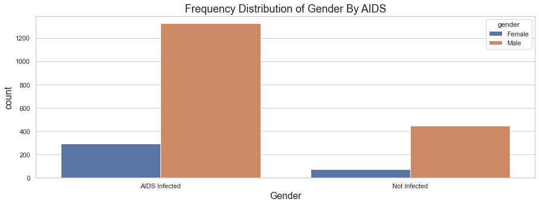

```python
plt.figure(figsize = (15,5))
sns.countplot(hue = 'gender' , x = 'infected', data = data_temp)
plt.title("Frequency Distribution of Gender By AIDS", fontsize = 18)
plt.xlabel("Gender", fontsize = 16)
plt.ylabel("count", fontsize = 16)
plt.show()
```

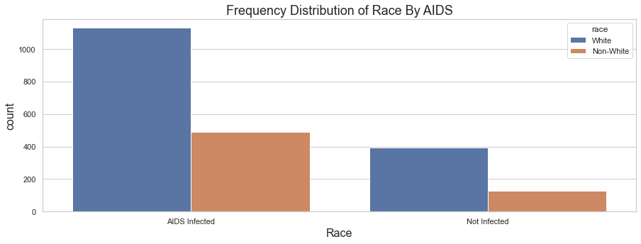

```python
plt.figure(figsize = (15,5))
sns.countplot(hue = 'race' , x = 'infected', data = data_temp)
plt.title("Frequency Distribution of Race By AIDS", fontsize = 18)
plt.xlabel("Race", fontsize = 16)
plt.ylabel("count", fontsize = 16)
plt.show()
```

## Statistical Analysis

```python
from scipy.stats import chi2_contingency
from scipy.stats import fisher_exact
for i in ['trt','strat']:
    chi2, pval,_,_ = chi2_contingency(pd.crosstab(data[i], data['infected']))
    print(i, '---', pval)
```

```
trt --- 3.871626196387431e-08
strat --- 8.930995099479137e-09
```

H0 : The categorical variable is not associated

H1 : The cateogircal variable is associated with the target variable

As the p-value is less than 0.05, we will reject the null hypothesis hence trt and strat are associated with the target variable

```python
for i in ['hemo', 'homo', 'drugs','oprior', 'z30', 'race','gender','str2','symptom','treat','offtrt']:

    hemo_con = pd.crosstab(data[i], data['infected'])
    odds_ratio, p_value = fisher_exact(hemo_con)

    print(i)
    print("Odds Ratio:", odds_ratio)
    print("p-value:", p_value)
    print(" ")
```

```
hemo
Odds Ratio: 0.9088579136690648
p-value: 0.650730265246819

homo
Odds Ratio: 1.3152876191904423
p-value: 0.012385153687250234

drugs
Odds Ratio: 0.6904146048882891
p-value: 0.020830710611957164

oprior
Odds Ratio: 1.7854497354497354
p-value: 0.06033155962347962

z30
Odds Ratio: 1.8315122659233185
p-value: 5.3448848457570115e-09

race
Odds Ratio: 0.7420283849580441
p-value: 0.01048848002097954

gender
Odds Ratio: 1.3413284886094554
p-value: 0.03852793392850348

str2
Odds Ratio: 1.8363649103139013
p-value: 9.276035741117753e-09

symptom
Odds Ratio: 2.058262595083232
p-value: 8.063604436412924e-09

treat
Odds Ratio: 0.5203922782751268
p-value: 4.8929178339773286e-09

offtrt
Odds Ratio: 1.5518044384023766
p-value: 2.156100161913127e-05
```

H0 : The categorical variable is not associated

H1 : The cateogircal variable is associated with the target variable

```python
import statsmodels.api as sm
from statsmodels.stats.outliers_influence import variance_inflation_factor
vif_data = data[['time', 'trt', 'age', 'wtkg', 'preanti', 'cd40', 'cd420', 'cd80', 'cd820']]

# Adding a constant column for the intercept
X = sm.add_constant(vif_data)

# Calculate VIF for each feature
vif = pd.DataFrame()
vif["Variable"] = X.columns
vif["VIF"] = [variance_inflation_factor(X.values, i) for i in range(X.shape[1])]

# Display VIF values
print(vif)
```

```
  Variable        VIF
0    const  62.496025
1     time   1.157193
2      trt   1.017077
3      age   1.038971
4     wtkg   1.037769
5  preanti   1.046116
6     cd40   1.879506
7    cd420   2.095445
8     cd80   2.956279
9    cd820   2.955609
```

The Variance Inflation Factor (VIF) is a measure used to detect multicollinearity in regression analysis. The numerical variables are independent of each other as VIF values are lower and not very high.

```python
X = sm.add_constant(data[['time', 'age', 'wtkg', 'preanti', 'cd40', 'cd420', 'cd80', 'cd820']])
y = data['infected']

# Fit logistic regression model
model = sm.Logit(y, X).fit()

# Print the summary
print(model.summary())
```

```
Optimization terminated successfully.
         Current function value: 0.363271
         Iterations 7
                           Logit Regression Results
==============================================================================
Dep. Variable:               infected   No. Observations:                 2139
Model:                          Logit   Df Residuals:                     2130
Method:                           MLE   Df Model:                            8
Date:                Sat, 03 Aug 2024   Pseudo R-squ.:                  0.3456
Time:                        19:50:18   Log-Likelihood:                -777.04
converged:                       True   LL-Null:                       -1187.5
Covariance Type:            nonrobust   LLR p-value:                6.398e-172
==============================================================================
                 coef    std err          z      P>|z|      [0.025      0.975]
------------------------------------------------------------------------------
const          1.9189      0.483      3.972      0.000       0.972       2.866
time          -0.0044      0.000    -19.104      0.000      -0.005      -0.004
age            0.0264      0.007      3.566      0.000       0.012       0.041
wtkg           0.0043      0.005      0.881      0.379      -0.005       0.014
preanti        0.0007      0.000      5.118      0.000       0.000       0.001
cd40           0.0010      0.001      1.272      0.203      -0.001       0.002
cd420         -0.0054      0.001     -7.136      0.000      -0.007      -0.004
cd80       -1.952e-05      0.000     -0.087      0.931      -0.000       0.000
cd820          0.0005      0.000      2.171      0.030    5.22e-05       0.001
==============================================================================
```

The model itself is highly significant, suggesting that, collectively, the predictors explain a significant portion of the variability in the target variable.

## Preparaing Data For ML Models:

```python
from sklearn.preprocessing import MinMaxScaler
from sklearn.model_selection import train_test_split

from sklearn.ensemble import AdaBoostClassifier
from sklearn.linear_model import LogisticRegression
from sklearn.tree import DecisionTreeClassifier
from sklearn.ensemble import RandomForestClassifier
from sklearn.naive_bayes import GaussianNB

from sklearn.metrics import accuracy_score
from sklearn.metrics import classification_report
from sklearn.metrics import f1_score
from sklearn.metrics import confusion_matrix
from sklearn.metrics import recall_score
from sklearn.metrics import precision_score
from sklearn.metrics import f1_score
from sklearn.metrics import roc_auc_score
```

```python
# List of columns to convert to category type
columns_to_convert = ["trt", "hemo", "homo", "drugs", "oprior", "z30", "str2",
                      "strat", "symptom", "treat", "offtrt", "race", "gender"]

# Convert the columns to category type
data[columns_to_convert] = data[columns_to_convert].astype('category')
```

```python
#converting categorical columns to numeric columns
df2 = pd.get_dummies(data)
```

```python
df2.head()
```

|  | time | age | wtkg | karnof | preanti | cd40 | cd420 | cd80 | cd820 | infected | ... | str2_1 | strat_1 | strat_2 | strat_3 | symptom_0 | symptom_1 | treat_0 | treat_1 | offtrt_0 | offtrt_1 |
| --- | --- | --- | --- | --- | --- | --- | --- | --- | --- | --- | --- | --- | --- | --- | --- | --- | --- | --- | --- | --- | --- |
| 0 | 948 | 48 | 89.8128 | 100 | 0 | 422 | 477 | 566 | 324 | 0 | ... | 0 | 1 | 0 | 0 | 1 | 0 | 0 | 1 | 1 | 0 |
| 1 | 1002 | 61 | 49.4424 | 90 | 895 | 162 | 218 | 392 | 564 | 1 | ... | 1 | 0 | 0 | 1 | 1 | 0 | 0 | 1 | 1 | 0 |
| 2 | 961 | 45 | 88.4520 | 90 | 707 | 326 | 274 | 2063 | 1893 | 0 | ... | 1 | 0 | 0 | 1 | 1 | 0 | 0 | 1 | 0 | 1 |
| 3 | 1166 | 47 | 85.2768 | 100 | 1399 | 287 | 394 | 1590 | 966 | 0 | ... | 1 | 0 | 0 | 1 | 1 | 0 | 0 | 1 | 1 | 0 |
| 4 | 1090 | 43 | 66.6792 | 100 | 1352 | 504 | 353 | 870 | 782 | 0 | ... | 1 | 0 | 0 | 1 | 1 | 0 | 1 | 0 | 1 | 0 |

5 rows × 39 columns

```python
#separating input and output features
X = df2.drop(columns = 'infected')
y = df2['infected']
```

```python
#scaling data
minmax = MinMaxScaler()
X_scaled = minmax.fit_transform(X)
```

```python
# Checking distribbution of output variable
df2['infected'].value_counts()
```

```
0    1618
1     521
Name: infected, dtype: int64
```

```python
#balancing data
from imblearn.over_sampling import RandomOverSampler
sm = RandomOverSampler()
X_s, y = sm.fit_resample(X_scaled, y)
```

```python
#splitting data into train and test data
X_train, X_test, y_train, y_test = train_test_split(X_s, y, test_size = 0.3, random_state = 42)
```

### Logistic Regression Model

```python
lr = LogisticRegression(random_state = 1)
lr.fit(X_train, y_train)
lr_preds = lr.predict(X_test)
lr_accuracy = round(accuracy_score(y_test, lr_preds), 2)
lr_precision = round(precision_score(y_test, lr_preds),2)
lr_auc = round(roc_auc_score(y_test, lr_preds), 2)
lr_f1 = round(f1_score(y_test, lr_preds), 2)
lr_recall = round(recall_score(y_test, lr_preds), 2)
print("Accuracy:\t", lr_accuracy,)
print("*"*30)
print("Precision:\t", lr_precision)
print("*"*30)
print("Recall:\t", lr_recall)
print("*"*30)
print("F1-score:\t", lr_accuracy)
print("*"*30)
print("Classification Report")
print(classification_report(y_test, lr_preds))
```

```
Accuracy:	 0.85
Precision:	 0.88
Recall:	 0.82
F1-score:	 0.85
Classification Report
              precision    recall  f1-score   support

           0       0.83      0.89      0.86       482
           1       0.88      0.82      0.85       489

    accuracy                           0.85       971
   macro avg       0.86      0.86      0.85       971
weighted avg       0.86      0.85      0.85       971
```

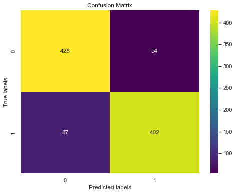

```python
# Specify class labels
class_labels = ["0", "1"]

# Calculate confusion matrix
cm = confusion_matrix(y_test, lr_preds)

# Create a heatmap of the confusion matrix
plt.figure(figsize=(8, 6))
sns.heatmap(cm, annot=True, fmt="d", cmap="viridis",
            xticklabels=class_labels, yticklabels=class_labels)
plt.xlabel('Predicted labels')
plt.ylabel('True labels')
plt.title('Confusion Matrix')
plt.show()
```

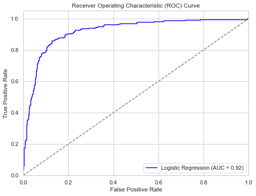

```python
from sklearn.metrics import roc_curve
# Predicting probabilities instead of class labels
lr_probs = lr.predict_proba(X_test)[:, 1]

# Calculate ROC curve
fpr, tpr, thresholds = roc_curve(y_test, lr_probs)

# Calculate AUC
lr_auc = roc_auc_score(y_test, lr_probs)
lr_auc = round(lr_auc, 2)

# Plot ROC curve
plt.figure(figsize=(8, 6))
plt.plot(fpr, tpr, label=f'Logistic Regression (AUC = {lr_auc})', color='blue')
plt.plot([0, 1], [0, 1], linestyle='--', color='gray')  # Diagonal line for random guessing
plt.xlim([0.0, 1.0])
plt.ylim([0.0, 1.05])
plt.xlabel('False Positive Rate')
plt.ylabel('True Positive Rate')
plt.title('Receiver Operating Characteristic (ROC) Curve')
plt.legend(loc='lower right')
plt.show()
```

## Random Forest Classifier

```python
rfc = RandomForestClassifier(random_state = 1)
rfc.fit(X_train, y_train)
rfc_preds = rfc.predict(X_test)
rfc_accuracy = round(accuracy_score(y_test, rfc_preds), 2)
rfc_precision = round(precision_score(y_test, rfc_preds),2)
rfc_auc = round(roc_auc_score(y_test, rfc_preds), 2)
rfc_f1 = round(f1_score(y_test, rfc_preds), 2)
rfc_recall = round(recall_score(y_test, rfc_preds), 2)
print("Accuracy:\t", rfc_accuracy,)
print("*"*30)
print("Precision:\t", rfc_precision)
print("*"*30)
print("Recall:\t", rfc_recall)
print("*"*30)
print("F1-score:\t", rfc_accuracy)
print("*"*30)
print("Classification Report")
print(classification_report(y_test, rfc_preds))
```

```
Accuracy:	 0.95
Precision:	 0.93
Recall:	 0.98
F1-score:	 0.95
Classification Report
              precision    recall  f1-score   support

           0       0.98      0.92      0.95       482
           1       0.93      0.98      0.95       489

    accuracy                           0.95       971
   macro avg       0.95      0.95      0.95       971
weighted avg       0.95      0.95      0.95       971
```

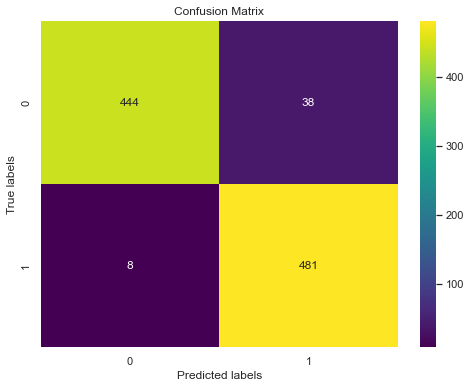

```python
# Specify class labels
class_labels = ["0", "1"]

# Calculate confusion matrix
cm = confusion_matrix(y_test, rfc_preds)

# Create a heatmap of the confusion matrix
plt.figure(figsize=(8, 6))
sns.heatmap(cm, annot=True, fmt="d", cmap="viridis",
            xticklabels=class_labels, yticklabels=class_labels)
plt.xlabel('Predicted labels')
plt.ylabel('True labels')
plt.title('Confusion Matrix')
plt.show()
```

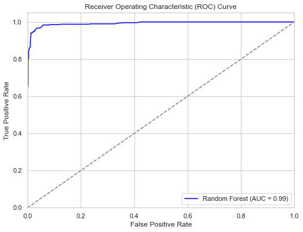

```python
# Predicting probabilities instead of class labels
rfc_probs = rfc.predict_proba(X_test)[:, 1]

# Calculate ROC curve
fpr, tpr, thresholds = roc_curve(y_test, rfc_probs)

# Calculate AUC
rfc_auc = roc_auc_score(y_test, rfc_probs)
rfc_auc = round(rfc_auc, 2)

# Plot ROC curve
plt.figure(figsize=(8, 6))
plt.plot(fpr, tpr, label=f'Random Forest (AUC = {rfc_auc})', color='blue')
plt.plot([0, 1], [0, 1], linestyle='--', color='gray')  # Diagonal line for random guessing
plt.xlim([0.0, 1.0])
plt.ylim([0.0, 1.05])
plt.xlabel('False Positive Rate')
plt.ylabel('True Positive Rate')
plt.title('Receiver Operating Characteristic (ROC) Curve')
plt.legend(loc='lower right')
plt.show()
```

## AdaBoost Classifier

```python
adb = AdaBoostClassifier(base_estimator = LogisticRegression(), n_estimators = 200, random_state = 1)
adb.fit(X_train, y_train)
adb_preds = adb.predict(X_test)
adb_accuracy = round(accuracy_score(y_test, adb_preds), 2)
adb_precision = round(precision_score(y_test, adb_preds),2)
adb_auc = round(roc_auc_score(y_test, adb_preds), 2)
adb_f1 = round(f1_score(y_test, adb_preds), 2)
adb_recall = round(recall_score(y_test, adb_preds), 2)
print("Accuracy:\t", adb_accuracy,)
print("*"*30)
print("Precision:\t", adb_precision)
print("*"*30)
print("Recall:\t", adb_recall)
print("*"*30)
print("F1-score:\t", adb_accuracy)
print("*"*30)
print("Classification Report")
print(classification_report(y_test, adb_preds))
```

```
Accuracy:	 0.85
Precision:	 0.88
Recall:	 0.81
F1-score:	 0.85
Classification Report
              precision    recall  f1-score   support

           0       0.82      0.89      0.85       482
           1       0.88      0.81      0.84       489

    accuracy                           0.85       971
   macro avg       0.85      0.85      0.85       971
weighted avg       0.85      0.85      0.85       971
```

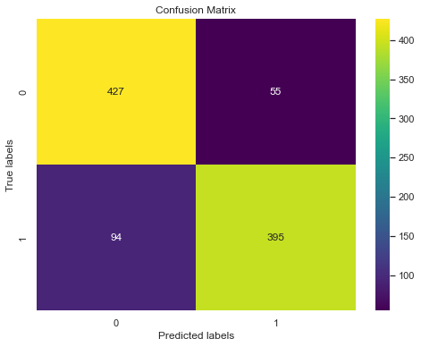

```python
# Specify class labels
class_labels = ["0", "1"]

# Calculate confusion matrix
cm = confusion_matrix(y_test, adb_preds)

# Create a heatmap of the confusion matrix
plt.figure(figsize=(8, 6))
sns.heatmap(cm, annot=True, fmt="d", cmap="viridis",
            xticklabels=class_labels, yticklabels=class_labels)
plt.xlabel('Predicted labels')
plt.ylabel('True labels')
plt.title('Confusion Matrix')
plt.show()
```

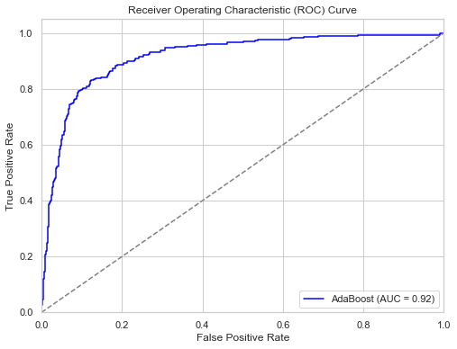

```python
# Predicting probabilities instead of class labels
adb_probs = adb.predict_proba(X_test)[:, 1]

# Calculate ROC curve
fpr, tpr, thresholds = roc_curve(y_test, adb_probs)

# Calculate AUC
adb_auc = roc_auc_score(y_test, adb_probs)
adb_auc = round(adb_auc, 2)

# Plot ROC curve
plt.figure(figsize=(8, 6))
plt.plot(fpr, tpr, label=f'AdaBoost (AUC = {adb_auc})', color='blue')
plt.plot([0, 1], [0, 1], linestyle='--', color='gray')  # Diagonal line for random guessing
plt.xlim([0.0, 1.0])
plt.ylim([0.0, 1.05])
plt.xlabel('False Positive Rate')
plt.ylabel('True Positive Rate')
plt.title('Receiver Operating Characteristic (ROC) Curve')
plt.legend(loc='lower right')
plt.show()
```

## Stacking Model

```python
from sklearn.ensemble import StackingClassifier
from sklearn.pipeline import Pipeline
# Create the stacking model
sclf = StackingClassifier(
    estimators=[('rf', rfc), ('adb', adb), ('lr', lr)],
    passthrough=False,
    final_estimator=LogisticRegression(),
    cv=5,
    n_jobs=-1
)

# Create a pipeline that includes preprocessing and the stacking classifier
stacking_pipeline = Pipeline(steps=[
    ('stacking', sclf)
])

# Fit the stacking model
stacking_pipeline.fit(X_train, y_train)
```

```
Pipeline(steps=[('stacking',
                 StackingClassifier(cv=5,
                                    estimators=[('rf',
                                                 RandomForestClassifier(random_state=1)),
                                                ('adb',
                                                 AdaBoostClassifier(base_estimator=LogisticRegression(),
                                                                    n_estimators=200,
                                                                    random_state=1)),
                                                ('lr',
                                                 LogisticRegression(random_state=1))],
                                    final_estimator=LogisticRegression(),
                                    n_jobs=-1))])
```

```python
# Evaluate the model on test data
stack_preds = stacking_pipeline.predict(X_test)
stack_accuracy = round(accuracy_score(y_test, stack_preds), 2)
stack_precision = round(precision_score(y_test, stack_preds),2)
stack_auc = round(roc_auc_score(y_test, stack_preds), 2)
stack_f1 = round(f1_score(y_test, stack_preds), 2)
stack_recall = round(recall_score(y_test, stack_preds), 2)
print("Accuracy:\t", stack_accuracy,)
print("*"*30)
print("Precision:\t", stack_precision)
print("*"*30)
print("Recall:\t", stack_recall)
print("*"*30)
print("F1-score:\t", stack_accuracy)
print("*"*30)
print("Classification Report")
print(classification_report(y_test, stack_preds))
```

```
Accuracy:	 0.96
Precision:	 0.95
Recall:	 0.98
F1-score:	 0.96
Classification Report
              precision    recall  f1-score   support

           0       0.98      0.94      0.96       482
           1       0.95      0.98      0.96       489

    accuracy                           0.96       971
   macro avg       0.96      0.96      0.96       971
weighted avg       0.96      0.96      0.96       971
```

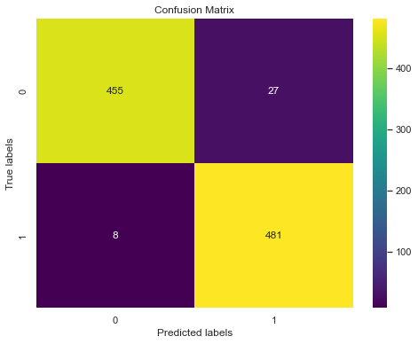

```python
# Specify class labels
class_labels = ["0", "1"]

# Calculate confusion matrix
cm = confusion_matrix(y_test, stack_preds)

# Create a heatmap of the confusion matrix
plt.figure(figsize=(8, 6))
sns.heatmap(cm, annot=True, fmt="d", cmap="viridis",
            xticklabels=class_labels, yticklabels=class_labels)
plt.xlabel('Predicted labels')
plt.ylabel('True labels')
plt.title('Confusion Matrix')
plt.show()
```

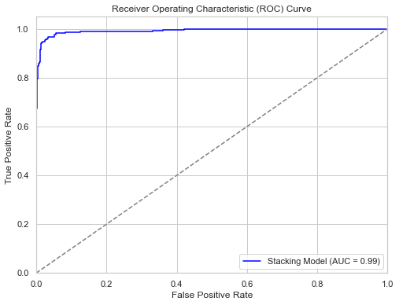

```python
# Predicting probabilities instead of class labels
stack_probs = sclf.predict_proba(X_test)[:, 1]

# Calculate ROC curve
fpr, tpr, thresholds = roc_curve(y_test, stack_probs)

# Calculate AUC
stack_auc = roc_auc_score(y_test, stack_probs)
stack_auc = round(stack_auc, 2)

# Plot ROC curve
plt.figure(figsize=(8, 6))
plt.plot(fpr, tpr, label=f'Stacking Model (AUC = {stack_auc})', color='blue')
plt.plot([0, 1], [0, 1], linestyle='--', color='gray')  # Diagonal line for random guessing
plt.xlim([0.0, 1.0])
plt.ylim([0.0, 1.05])
plt.xlabel('False Positive Rate')
plt.ylabel('True Positive Rate')
plt.title('Receiver Operating Characteristic (ROC) Curve')
plt.legend(loc='lower right')
plt.show()
```

## Comparison of Models

```python
perf = pd.DataFrame({'Model':['Logistic Regression', 'Random Forest', 'Ada Boost', 'Stacking Model'],
                    'Accuracy':[lr_accuracy, rfc_accuracy, adb_accuracy, stack_accuracy],
                    'Precision':[lr_precision, rfc_precision, adb_precision, stack_precision],
                    'Recall':[lr_recall, rfc_recall, adb_recall, stack_recall],
                    'F1-score':[lr_f1, rfc_f1, adb_f1, stack_f1]})
```

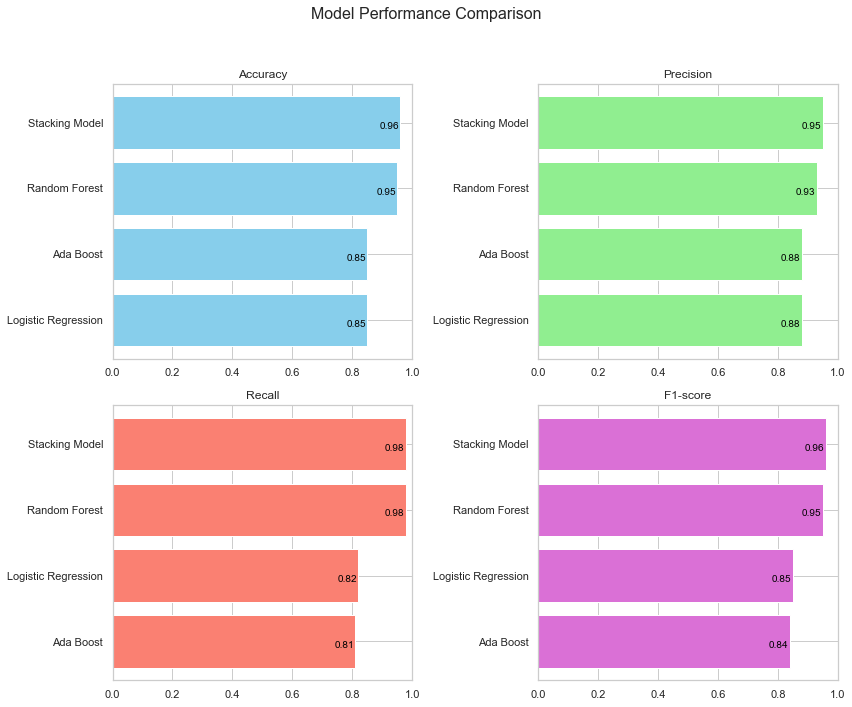

```python
# Sort the DataFrame for each metric in descending order
perf_sorted_accuracy = perf.sort_values(by='Accuracy', ascending=True)
perf_sorted_precision = perf.sort_values(by='Precision', ascending=True)
perf_sorted_recall = perf.sort_values(by='Recall', ascending=True)
perf_sorted_f1 = perf.sort_values(by='F1-score', ascending=True)

# Set up the subplots
fig, axes = plt.subplots(2, 2, figsize=(12, 10))
fig.suptitle('Model Performance Comparison', fontsize=16)

# Plot Accuracy
axes[0, 0].barh(perf_sorted_accuracy['Model'], perf_sorted_accuracy['Accuracy'], color='skyblue')
axes[0, 0].set_title('Accuracy')
axes[0, 0].set_xlim(0, 1)
for i in axes[0, 0].patches:
    axes[0, 0].text(i.get_width() - 0.07, i.get_y() + 0.3, f'{i.get_width():.2f}', fontsize=10, color='black')

# Plot Precision
axes[0, 1].barh(perf_sorted_precision['Model'], perf_sorted_precision['Precision'], color='lightgreen')
axes[0, 1].set_title('Precision')
axes[0, 1].set_xlim(0, 1)
for i in axes[0, 1].patches:
    axes[0, 1].text(i.get_width()  - 0.07, i.get_y() + 0.3, f'{i.get_width():.2f}', fontsize=10, color='black')

# Plot Recall
axes[1, 0].barh(perf_sorted_recall['Model'], perf_sorted_recall['Recall'], color='salmon')
axes[1, 0].set_title('Recall')
axes[1, 0].set_xlim(0, 1)
for i in axes[1, 0].patches:
    axes[1, 0].text(i.get_width()  - 0.07, i.get_y() + 0.3, f'{i.get_width():.2f}', fontsize=10, color='black')

# Plot F1-score
axes[1, 1].barh(perf_sorted_f1['Model'], perf_sorted_f1['F1-score'], color='orchid')
axes[1, 1].set_title('F1-score')
axes[1, 1].set_xlim(0, 1)
for i in axes[1, 1].patches:
    axes[1, 1].text(i.get_width()  - 0.07, i.get_y() + 0.3, f'{i.get_width():.2f}', fontsize=10, color='black')

# Adjust layout to prevent overlap
plt.tight_layout(rect=[0, 0, 1, 0.95])
plt.show()
```